# Final assignment

Herman Savinen (herman.savinen@helsinki.fi)

February 27, 2017

*This little study aimed to examine how people could be grouped to different learning profiles based on their learning approaches, attitude and learning success. K-means clustering was performed with an international survey data to group the observations and Linear Discriminant anaysis was used to examine the differences between the 3 discovered clusters of learners. According to this analysis, surface learning approach defined the cluser with lowest test scores, while deep and strategic learning and positive attitude were more present with cluster that had higher test scores.*

```r
learning2014 <- read.csv("C:/Users/Admin/Documents/GitHub/IODS-project/data/learning2014.csv")
```

The data originates from an international survey of approaches to learning and holds 166 observations of 7 variables. Following variables have been combined from several answers:

- Deep, measuring deep learning approach
- Stra, measuring strategic learning approach
- Surf, measuring surface learning approach

The structure and dimensions of the data:

```r
str(learning2014)
```

```
## 'data.frame':    166 obs. of  7 variables:
##  $ gender  : Factor w/ 2 levels "F","M": 1 2 1 2 2 1 2 1 2 1 ...
##  $ Age     : int  53 55 49 53 49 38 50 37 37 42 ...
##  $ Attitude: num  3.7 3.1 2.5 3.5 3.7 3.8 3.5 2.9 3.8 2.1 ...
##  $ Deep    : num  3.75 2.88 3.88 3.5 3.75 ...
##  $ Stra    : num  3.38 2.75 3.62 3.12 3.62 ...
##  $ Surf    : num  2.58 3.17 2.25 2.25 2.83 ...
##  $ Points  : int  25 12 24 10 22 21 21 31 24 26 ...
```

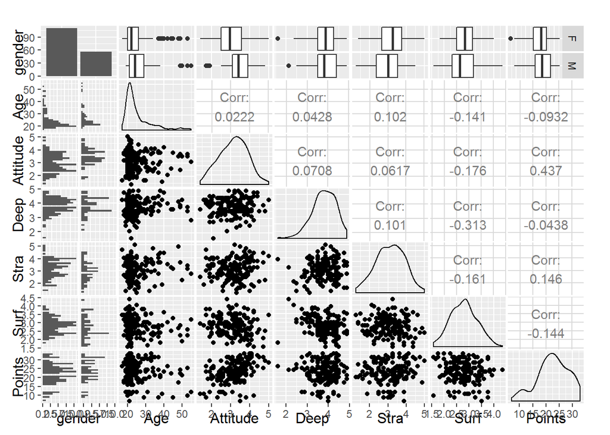

```r
library(ggplot2)
library(GGally)
ggpairs(learning2014)
```

So the inital hypothesis is that there are diffrents student “types” with different combinations of learning aproaches, attitudes and levels of success. We can try to explore these hypothetical groups by statistical clustering.

The method chosen here is k-means clustering, which tries to partition n observations into k clusters in which each observation belongs to the cluster with the nearest mean. This works best if the variables in question are continuous and have the same variances so next up is the standardization of variables.

```r
learning <- subset(learning2014, select=-gender)
learning <- subset(learning, select=-Age)
learning_scaled <- scale(learning)
learning_scaled <- as.data.frame(learning_scaled)
summary(learning_scaled)
```

```
##     Attitude             Deep              Stra
##  Min.   :-2.38766   Min.   :-3.7978   Min.   :-2.42441
##  1st Qu.:-0.74362   1st Qu.:-0.5177   1st Qu.:-0.64293
##  Median : 0.07841   Median : 0.1383   Median : 0.08585
##  Mean   : 0.00000   Mean   : 0.0000   Mean   : 0.00000
##  3rd Qu.: 0.76342   3rd Qu.: 0.7943   3rd Qu.: 0.65269
##  Max.   : 2.54447   Max.   : 1.8877   Max.   : 2.43416
##       Surf              Points
##  Min.   :-2.27633   Min.   :-2.66619
##  1st Qu.:-0.70056   1st Qu.:-0.63052
##  Median : 0.08733   Median : 0.04803
##  Mean   : 0.00000   Mean   : 0.00000
##  3rd Qu.: 0.71764   3rd Qu.: 0.85381
##  Max.   : 2.92373   Max.   : 1.74442
```

With the scaled variables, k-means is performed using the euclidean distance matrix. It is done muliple times with different numbers of clusters since the right number can be decided by looking at how the total of within cluster sum of squares (WCSS). The best number should be the one where WCSS drops rapidly.

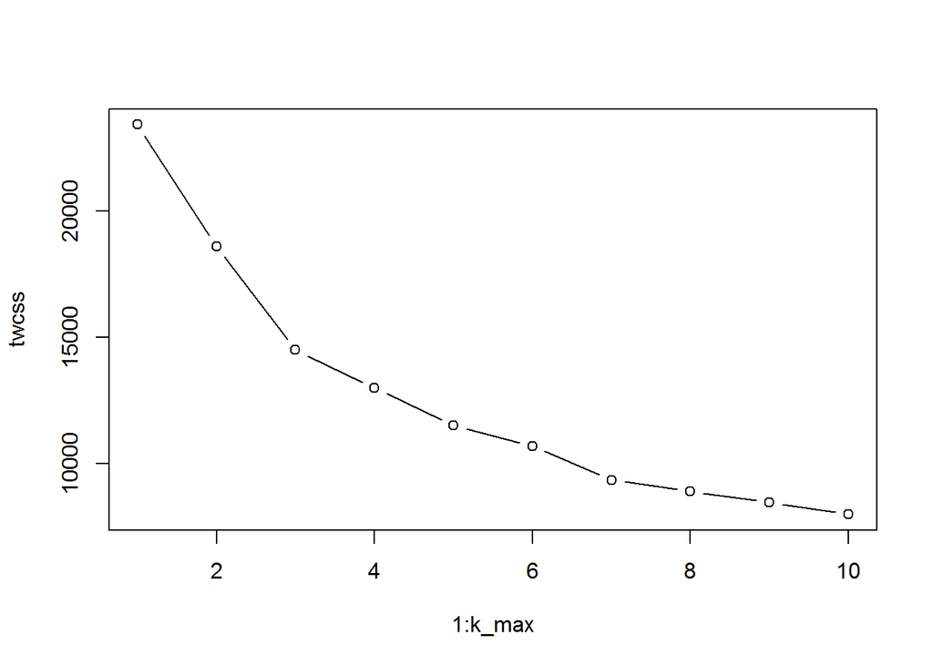

```r
set.seed(123)
dist_learning <- dist(learning_scaled)
k_max <- 10
twcss <- sapply(1:k_max, function(k){kmeans(dist_learning, k)$tot.withinss})
plot(1:k_max, twcss, type='b')
```

Judging from the plot, 3 clusters is appropriate.

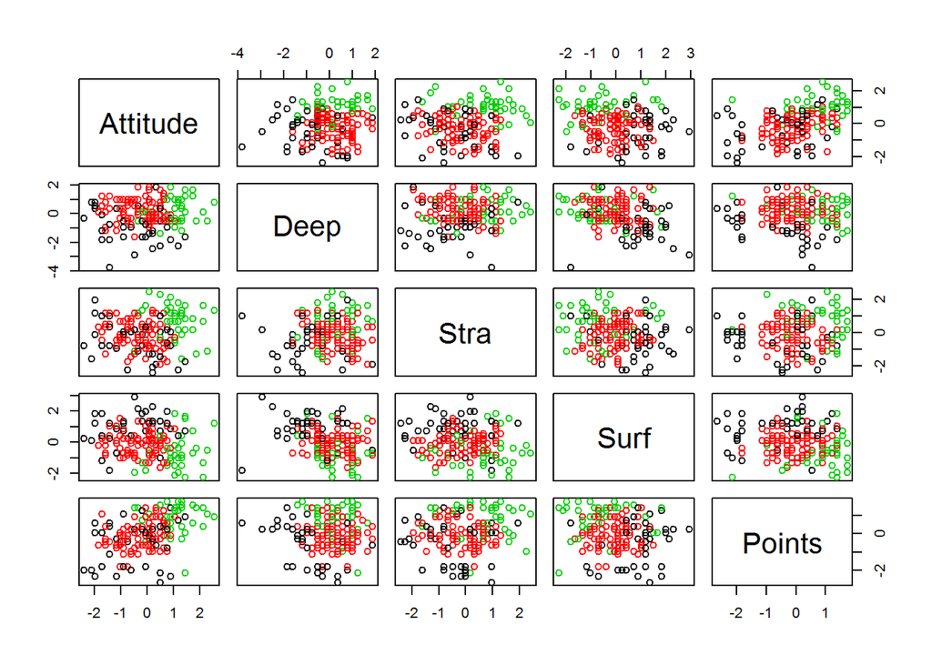

```r
km <-kmeans(dist_learning, centers = 3)
pairs(learning_scaled, col = km$cluster)
```

Now that we have our three clusters of students, the question that comes up is what makes the differences between them? Liner Discriminant Analysis can be used to answer this.

```r
library(MASS)
learning_scaled$cl <- km$cluster
lda.fit <- lda(cl ~ ., data = learning_scaled)

lda.arrows <- function(x, myscale = 1, arrow_heads = 0.1, color = "red", tex = 0.75, choices = c(1,2)){
  heads <- coef(x)
  arrows(x0 = 0, y0 = 0,
         x1 = myscale * heads[,choices[1]],
         y1 = myscale * heads[,choices[2]], col=color, length = arrow_heads)
  text(myscale * heads[,choices], labels = row.names(heads),
       cex = tex, col=color, pos=3)
}


lda.fit
```

```
## Call:
## lda(cl ~ ., data = learning_scaled)
##
## Prior probabilities of groups:
##         1         2         3
## 0.2289157 0.5361446 0.2349398
##
## Group means:
##     Attitude       Deep        Stra        Surf     Points
## 1 -0.4984515 -0.8744850 -0.49802667  0.86277904 -0.6082034
## 2 -0.2602549  0.2513395 -0.09702454 -0.08972124 -0.1044539
## 3  1.0795857  0.2784926  0.70667172 -0.63590804  0.8309777
##
## Coefficients of linear discriminants:
##                 LD1        LD2
## Attitude  0.7828451  0.7545971
## Deep      0.4980307 -0.8078209
## Stra      0.6218828  0.2663023
## Surf     -0.5907714  0.2836043
## Points    0.5760399 -0.2093523
##
## Proportion of trace:
##    LD1    LD2
## 0.9088 0.0912
```

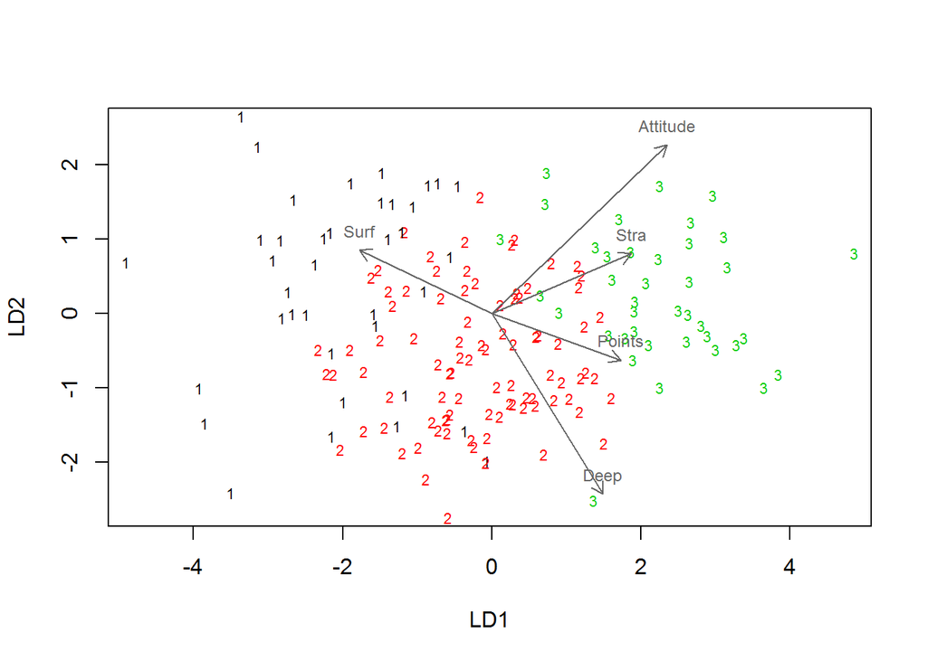

```r
plot(lda.fit, col=as.numeric(learning_scaled$cl), dimen=2)
lda.arrows(lda.fit, myscale = 3, col = "#666666")
```

From the proportion of trace, it’s evident that Linear discriminant 1 is the more important one. Basically the surface learning approach is opposed to all the other variables, especially points. One could interpret the three clusters as bad students, mediocre students, and good sudents. This tells the same story as the first exploratry analysis with plotting. Low points are associated with the surface learning approach and bad attitude.